# Case Study 2

xuyan

November 7, 2015

## Introduction:

```r
library(XML)
library(RCurl)
```

```r
StopWords = readLines("http://jmlr.csail.mit.edu/papers/volume5/lewis04a/a11-smart-stop-list/english.stop")

asWords = function(txt, stopWords = StopWords, stem = FALSE)
{
  words = unlist(strsplit(txt, '[[:space:]!.,;#:()/"]+'))
  words = words[words != ""]
  if(stem && require(Rlibstemmer))
     words = wordStem(words)
  i = tolower(words) %in% tolower(stopWords)
  words[!i]
}

removeStopWords = function(x, stopWords = StopWords)
     {
         if(is.character(x))
             setdiff(x, stopWords)
         else if(is.list(x))
             lapply(x, removeStopWords, stopWords)
         else
             x
     }

cy.getFreeFormWords = function(doc, stopWords = StopWords)
     {
         nodes = getNodeSet(doc, "//div[@class='job-details']/
                                 div[@data-section]")
         if(length(nodes) == 0)
             nodes = getNodeSet(doc, "//div[@class='job-details']//p")

         if(length(nodes) == 0)
             warning("did not find any nodes for the free form text in ",
                     docName(doc))

         words = lapply(nodes,
                        function(x)
                            strsplit(xmlValue(x),
                                     "[[:space:][:punct:]]+"))

         removeStopWords(words, stopWords)
     }
```

** Question 1**: Implement the following functions. Use the code we explored to extract the date posted, skill sets and salary and location information from the parsed HTML document.

```r
cy.getSkillList = function(doc)
{
  lis = getNodeSet(doc, "//div[@class = 'skills-section']//
                         li[@class = 'skill-item']//
                         span[@class = 'skill-name']")

  sapply(lis, xmlValue)
}

cy.getDatePosted = function(doc)
  { xmlValue(getNodeSet(doc,
                     "//div[@class = 'job-details']//
                        div[@class='posted']/
                        span/following-sibling::text()")[[1]],
    trim = TRUE)
}

cy.getLocationSalary = function(doc)
{
  ans = xpathSApply(doc, "//div[@class = 'job-info-main'][1]/div", xmlValue)
  names(ans) = c("location", "salary")
  ans
}

# cy.getSkillList(cydoc)
# cy.getLocationSalary(cydoc)
```

The function `cy.ReadPost()` given below reads each job post. This function implements three other functions: `cy.getFreeFormWords()`, `cy.getSkillList()`, and `cy.getLocationSalary()`.

```r
cy.readPost = function(u, stopWords = StopWords, doc = htmlParse(u))
  {
    ans = list(words = cy.getFreeFormWords(doc, stopWords),
         datePosted = cy.getDatePosted(doc),
         skills = cy.getSkillList(doc))
    o = cy.getLocationSalary(doc)
    ans[names(o)] = o
    ans
}
# cyFuns = list(readPost = function(u, stopWords = StopWords, doc=htmlParse(u)))
```

**Reading posts programmatically** The function `cy.ReadPost()` allows us to read a single post from CyberCoders.com in a very general format. All we need is the URL for the post. Now, let’s see about obtaining the URLs using a computer program.

```r
# Obtain URLs for job posts
txt = getForm("http://www.cybercoders.com/search/", searchterms = '"Data Scientist"',
              searchlocation = "",  newsearch = "true", sorttype = "")
# Parse the links
doc = htmlParse(txt, asText = TRUE)
links = getNodeSet(doc, "//div[@class = 'job-title']/a/@href")
# Save the links in the vector joblinks
joblinks <- getRelativeURL(as.character(links), "http://www.cybercoders.com/search/")
# Read the posts
#posts <- lapply(joblinks,cy.readPost)

cy.getPostLinks = function(doc, baseURL = "http://www.cybercoders.com/search/")
  {
    if(is.character(doc)) doc = htmlParse(doc)
    links = getNodeSet(doc, "//div[@class = 'job-title']/a/@href")
    getRelativeURL(as.character(links), baseURL)
}

cy.readPagePosts = function(doc, links = cy.getPostLinks(doc, baseURL),
baseURL = "http://www.cybercoders.com/search/")
  {
    if(is.character(doc)) doc = htmlParse(doc)
    lapply(links, cy.readPost)
 }

## Testing the function with the parsed version of the first page of results in object doc
posts = cy.readPagePosts(doc)
sapply(posts,`[[`, "salary")
```

```
##           /data-scientist-job-214172           /data-scientist-job-200988
##            "Full-time $100k - $160k"            "Full-time $100k - $160k"
##           /data-scientist-job-184567           /data-scientist-job-230442
##            "Full-time $130k - $160k"            "Full-time $140k - $160k"
##           /data-scientist-job-234161           /data-scientist-job-223862
## "Full-time Compensation Unspecified" "Full-time Compensation Unspecified"
##           /data-scientist-job-230135           /data-scientist-job-235549
## "Full-time Compensation Unspecified"            "Full-time $120k - $150k"
##           /data-scientist-job-232102           /data-scientist-job-193909
##            "Full-time $100k - $160k"            "Full-time $110k - $150k"
##           /data-scientist-job-199692           /data-scientist-job-221652
## "Full-time Compensation Unspecified"             "Full-time $75k - $150k"
##           /data-scientist-job-224228           /data-scientist-job-227142
##            "Full-time $100k - $150k"            "Full-time $100k - $130k"
##           /data-scientist-job-227433           /data-scientist-job-227439
##             "Full-time $75k - $100k"            "Full-time $120k - $140k"
##           /data-scientist-job-227443           /data-scientist-job-233385
##             "Full-time $90k - $110k"            "Full-time $110k - $150k"
##           /data-scientist-job-147098           /data-scientist-job-227151
##            "Full-time $120k - $150k"             "Full-time $90k - $110k"
```

```r
summary(sapply(posts, function(x) length(unlist(x$words))))
```

```
##    Min. 1st Qu.  Median    Mean 3rd Qu.    Max.
##    66.0    99.0   121.0   143.0   173.5   338.0
```

**Question:** Test the `cy.getFreeFromWords()` function on several different posts.

```r
# Test of concept
# getNodeSet(doc, "//a[@rel='next']/@href")[[1]]
## A function to get all pages
cy.getNextPageLink = function(doc, baseURL = docName(doc))
{
  if(is.na(baseURL))
     baseURL = "http://www.cybercoders.com/"
  link = getNodeSet(doc, "//li[@class = 'lnk-next pager-item ']/a/@href")
  if(length(link) == 0)
    return(character())
    link2 <- gsub("./", "search/",link[[1]])
 getRelativeURL(link2, baseURL)
}

# Test the above function
tmp = cy.getNextPageLink(doc, "http://www.cybercoders.com")
```

Now we have all we need to retrieve all job posts on Cyber Coders for a given search query. The following function puts it all together into a function that we can call with a search string for a job of interest. The function submits the initial query and then reads the posts from each result page.

```r
cyberCoders =
function(query)
{
   txt = getForm("http://www.cybercoders.com/search/",
                  searchterms = query,  searchlocation = "",
                  newsearch = "true",  sorttype = "")
   doc = htmlParse(txt)

   posts = list()
   while(TRUE) {
       posts = c(posts, cy.readPagePosts(doc))
       nextPage = cy.getNextPageLink(doc)
       if(length(nextPage) == 0)
          break

       nextPage = getURLContent(nextPage)
       doc = htmlParse(nextPage, asText = TRUE)
   }
   invisible(posts)
}

dataSciPosts = cyberCoders("Data Scientist")
tt = sort(table(unlist(lapply(dataSciPosts, `[[`, "skills"))),
           decreasing = TRUE)
tt[tt >= 2]
```

```
##
##                              Machine Learning
##                                            95
##                                        Python
##                                            88
##                                   Data Mining
##                                            71
##                                             R
##                                            68
##                                        Hadoop
##                                            58
##                                           SQL
##                                            38
##                                          Java
##                                            25
##                                        Matlab
##                                            22
##                                           SAS
##                                            21
##                                         Scala
##                                            17
##                                      Big Data
##                                            16
##                                    Algorithms
##                                            15
##                                         Linux
##                                            15
##                                  Apache Spark
##                                            14
##                          Predictive Analytics
##                                            10
##                                         NoSQL
##                                             9
##                                         SPARK
##                                             9
##                                    Statistics
##                                             9
##                                           C++
##                                             8
##                                 Data Modeling
```

[output cut: 152 more lines]

```
##                                             2
##                        statistical techniques
##                                             2
##                    Strong Econometric mindset
##                                             2
##                Strong Math/Physics background
##                                             2
##                                          Unix
##                                             2
##                                    Unix/Linux
##                                             2
##                                           VBA
##                                             2
##                          Virtual Environments
##                                             2
```

## Clean up the skills and combine the categories.

```r
tt.2 <- tt[tt>=2]
tt.2[1] <- tt.2[1]+tt.2[32]+tt.2[45]
tt.2[2] <- tt.2[2]+tt.2[84]+tt.2[85]+tt.2[86]
tt.2[3] <- tt.2[3]+tt.2[19]+tt.2[20]+tt.2[21]+tt.2[28]+tt.2[60]+tt.2[61]+tt.2[62] #name changed to "data mining/analysis"
tt.2[4] <- tt.2[4]+tt.2[50]+tt.2[84]+tt.2[85]+tt.2[86]
tt.2[6] <- tt.2[6]+tt.2[23]+tt.2[47]+tt.2[79]+tt.2[92]+tt.2[93]
tt.2[8] <- tt.2[8]+tt.2[85]
tt.2[9] <- tt.2[9]+tt.2[89]
tt.2[10] <- tt.2[10]+tt.2[27]+tt.2[39]+tt.2[72]
tt.2[12] <- tt.2[12]+tt.2[36]
tt.2[13] <- tt.2[13]+tt.2[99]+tt.2[100] #change the name to "Unix/Linux"
tt.2[14] <- tt.2[14]+tt.2[16]  #change the name to "Spark"
tt.2[15] <- tt.2[15]+tt.2[30]+tt.2[80]+tt.2[81]
tt.2[17] <- tt.2[17]+tt.2[24]+tt.2[25]+tt.2[54]+tt.2[95]+tt.2[96]
tt.2[18] <- tt.2[18]+tt.2[33]  #change the name to "C/C++"
tt.2[22] <- tt.2[22]+tt.2[74]
tt.2[31] <- tt.2[31]+tt.2[40]
tt.2[34] <- tt.2[34]+tt.2[71]
tt.2[42] <- tt.2[42]+tt.2[66]
tt.2[51] <- tt.2[51]+tt.2[89]


names(tt.2)[3] <- "Data Mining/Analysis"
names(tt.2)[13] <- "Unix/Linux"
names(tt.2)[14] <- "Spark"
names(tt.2)[18] <- "C/C++"

#Get the new skills list by deleting the merged ones
tt.3 <- tt.2[-c(32,45,84,85,86,19,20,21,28,60,61,62,50,84,85,86,23,
                47,79,92,93,89,27,39,72,36,99,100,16,30,80,81,24,25,
                54,95,96,33,40,71,66,89,74)]

#Sort the list by descending order
tt.4 <- sort(tt.3,decreasing=T)
```

## Delete those skills with only two or three appearance. I assume that those skills are of less importance.

```r
tt.5 <- tt.4[tt.4>=4]
#Define the importance of each skill as its mentioned times.
Importance <- as.numeric(tt.5)

#Rename the skills with their order added.
Skills <- c("01. Data Mining/Analysis", "02. Machine Learning",
            "03. Python","04. R",
            "05. Hadoop", "06. SQL",
            "07. Statistics", "08. Big Data",
            "09. Java", "10. Matlab",
            "11. Spark", "12. SAS",
            "13. Predictive Analytics","14. Unix/Linux",
            "15. Algorithms", "16. Scala",
            "17. C/C++", "18. Mapreduce",
            "19. Data Visualization", "20. AWS",
            "21. Natural Language Processing", "22. Hive",
            "23. Excel", "24. SPSS","25. Tableau")
```

## Visualize the relation between skills and their importance. Here I use a barplot.

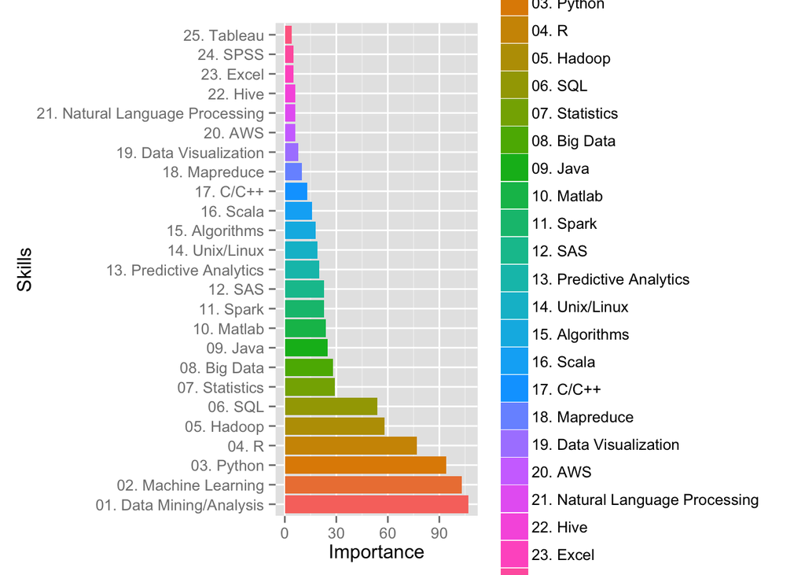

```r
library(ggplot2)
qplot(y=Importance,x=Skills,geom="bar",stat="identity",fill=Skills)+coord_flip()
```

```r
sum(Importance[1:4])/sum(Importance)
```

```
## [1] 0.4878361
```

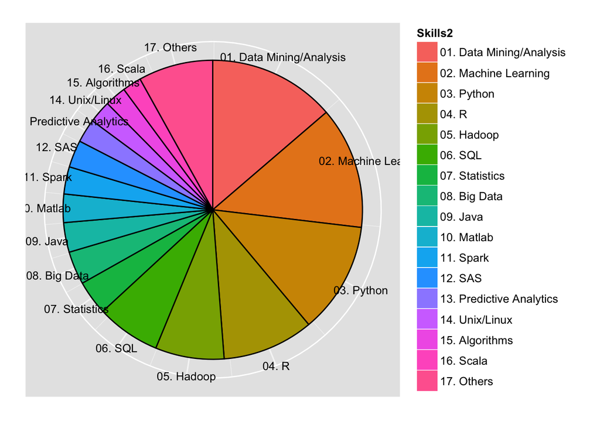

```r
#Pie charts
Skills2 <- c("01. Data Mining/Analysis", "02. Machine Learning",
            "03. Python","04. R",
            "05. Hadoop", "06. SQL",
            "07. Statistics", "08. Big Data",
            "09. Java", "10. Matlab",
            "11. Spark", "12. SAS",
            "13. Predictive Analytics","14. Unix/Linux",
            "15. Algorithms", "16. Scala",
            "17. Others")
Importance2<-Importance
Importance2[17] <- sum(Importance[17:25])
Importance2 <- Importance2[-(18:25)]

pie.skills <- data.frame(Skills2,Importance2)

pp <- ggplot(pie.skills,aes(x=1,y=Importance2,fill=Skills2)) +geom_bar(stat="identity")+coord_polar(theta='y')
pp <- pp +  geom_bar(stat="identity", color='black') +
        guides(fill=guide_legend(override.aes=list(colour=NA)))
pp <- pp +
    theme(axis.ticks=element_blank(),
          axis.title=element_blank(),
          axis.text.y=element_blank())

y.breaks <- cumsum(pie.skills$Importance2) - pie.skills$Importance2/2

pp <- pp +
    theme(axis.text.x=element_text(color='black')) +
    scale_y_continuous(
        breaks=y.breaks,
        labels=pie.skills$Skills2
    )

print(pp)
```

## Conclusion:

The first four skills are most important, which take up almost 50% total mentioned times. They are “Data Mining”, “Machine Learning”, “Python”, and “R”. These findings implies a great importance of programming. The next two skills are Hadoop and SQL, showing the importance of capability of managing big data and database nowadays. After that the importance decreases rapidly, but they still reveals the importance of programming because JAVA, Matlab, SAS and some other languages are also included.